# Human Activity Recognition

Jeff Shilling

Saturday, February 21, 2015

## Description

This assignment attempts to build a model that uses data from wearable sensors to predict the performance quality of a subject curling a dumbbell. The prediction uses the sensor data to determine if the subject performed the curl correctly or made one of four common mistakes. The data come from here:

> Velloso, E.; Bulling, A.; Gellersen, H.; Ugulino, W.; Fuks, H. Qualitative Activity Recognition of Weight Lifting Exercises. Proceedings of 4th International Conference in Cooperation with SIGCHI (Augmented Human ’13) . Stuttgart, Germany: ACM SIGCHI, 2013.

### Data Preparation

Load the data:

```r
file <- "pml-training.csv"
URL <- "https://d396qusza40orc.cloudfront.net/predmachlearn/pml-training.csv"
originalData <- read.csv(file, header = T, fill = TRUE, stringsAsFactors=FALSE)
dim(originalData)
```

```
## [1] 19622   160
```

A quick check shows there are 160 variables. I cleaned up the data in the following steps:  
1. Removed summary rows indicated by the new_window variable 2. Changed the response (classe) variable to a factor 3. Dropped the labeling variables as non-predictors 4. Removed variables with so many #DIV/0! values they were identified as characters 6. Removed variables with too many NA values for random forest to handle 7. Removed variables with near zero variance

```r
working <- originalData
### remove summary rows and make the response variable a factor
working <- working[working$new_window=="no",]
working$classe <- as.factor(working$classe)
### drop the non-predictive labelling variables
working <- working[,-c(1:6)]
### remove variables that won't work with random forest
### sepcifically, variable that are characters because of missing data
keep <- !(sapply(working, is.character))
working <- working[,keep]
missing <- sapply(working, function(x) sum(is.na(x)) > 0)
working <- working[,!missing]
### remove variables with near zero variance
NZV <- nearZeroVar(working[,-1], saveMetrics=TRUE)$nzv
working <- working[,!NZV]
dim(working)
```

```
## [1] 19216    54
```

The clean up reduce the number of potential predictors to 53.

I split the “working” dataset into a traing dataset and a “test” dataset that I call “validation” here to distinguish it from the official test data.

```r
set.seed(6789)
inTrain <- createDataPartition(y=working$classe , p=0.8, list=FALSE)
training <- working[inTrain,]
validation <- working[-inTrain,]
```

### Build a machine learning algorithm to predict activity quality from activity monitors

Because of the advice in week 3, lecture 3 that “[r]andom forests are usually one of the two top performing algorithms along with boosting in prediction contests,” I chose to try that first.

```r
fit <- randomForest(classe ~ ., data=training)
fit
```

```
##
## Call:
##  randomForest(formula = classe ~ ., data = training)
##                Type of random forest: classification
##                      Number of trees: 500
## No. of variables tried at each split: 7
##
##         OOB estimate of  error rate: 0.21%
## Confusion matrix:
##      A    B    C    D    E class.error
## A 4377    0    0    0    0 0.000000000
## B    4 2970    1    0    0 0.001680672
## C    0    7 2675    0    0 0.002609993
## D    0    0   16 2501    1 0.006751390
## E    0    0    0    4 2819 0.001416932
```

That appears to be a pretty good model, but also one that could easily be overfit.

### The expected out of sample error to be and estimated error using cross-validation

In addition to the built in cross-validation that random forest provided, I tested the model against my reserved validation dataset.

```r
predictions <- predict(fit, validation)
confusionMatrix(predictions, validation$classe)
```

```
## Confusion Matrix and Statistics
##
##           Reference
## Prediction    A    B    C    D    E
##          A 1094    2    0    0    0
##          B    0  740    2    0    0
##          C    0    1  667    1    0
##          D    0    0    1  628    0
##          E    0    0    0    0  705
##
## Overall Statistics
##
##                Accuracy : 0.9982
##                  95% CI : (0.9962, 0.9993)
##     No Information Rate : 0.2848
##     P-Value [Acc > NIR] : < 2.2e-16
##
##                   Kappa : 0.9977
##  Mcnemar's Test P-Value : NA
##
## Statistics by Class:
##
##                      Class: A Class: B Class: C Class: D Class: E
## Sensitivity            1.0000   0.9960   0.9955   0.9984   1.0000
## Specificity            0.9993   0.9994   0.9994   0.9997   1.0000
## Pos Pred Value         0.9982   0.9973   0.9970   0.9984   1.0000
## Neg Pred Value         1.0000   0.9990   0.9991   0.9997   1.0000
## Prevalence             0.2848   0.1934   0.1744   0.1638   0.1835
## Detection Rate         0.2848   0.1927   0.1737   0.1635   0.1835
## Detection Prevalence   0.2853   0.1932   0.1742   0.1638   0.1835
## Balanced Accuracy      0.9996   0.9977   0.9974   0.9990   1.0000
```

Here is the plot of those predictions followed by the Out Of Sample results:

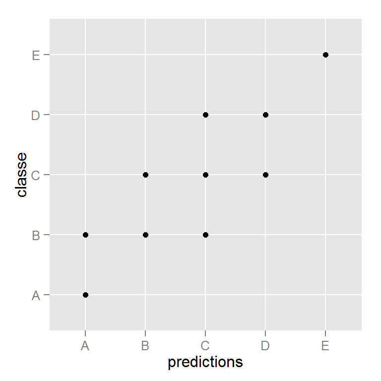

```r
qplot(predictions,classe,data=validation)
```

```r
outOfSample <- data.frame(Accuracy = sum(predictions == validation$classe)/length(predictions))
outOfSample$Error <- 1 - outOfSample$Accuracy
print(outOfSample, digits=3)
```

```
##   Accuracy   Error
## 1    0.998 0.00182
```

The estimated Out of Sample Error rate is 0.182%.

### Final Application

I created predictions using the model generated by random forest as follows (not executed):

```r
#  testPredictions <- as.character(predict(fit, testing))
```